# Exercise 2

for Advanced Methods for Regression and Classification

Dzhamilia Kulikieva

31.10.2024”

## Data investigation and preparation

This data set contains information about construction costs (df$y) of real estate single-family residential apartments in Tehran, Iran. Let’s see the structure of the data and its variables format.

```r
load("/Users/djem/Downloads/building.RData")
head(df)
```

```
##          y START.YEAR START.QUARTER COMPLETION.YEAR COMPLETION.QUARTER PhysFin1
## 1 7.696213         81             1              85                  1        1
## 2 8.517193         84             1              89                  4        1
## 3 7.090077         78             1              81                  4        1
## 4 5.105945         72             2              73                  2        1
## 5 8.612503         87             1              90                  2        1
## 6 8.556414         87             1              90                  1        1
##   PhysFin2 PhysFin3 PhysFin4 PhysFin5 PhysFin6 PhysFin7 PhysFin8   Econ1 Econ2
## 1     3150      920    598.5      190  1010.84       16     1200 6713.00  56.2
## 2     7600     1140   3040.0      400   963.81       23     2900 3152.00 106.0
## 3     4800      840    480.0      100   689.84       15      630 1627.00  41.0
## 4      685      202     13.7       20   459.54        4      140 2580.93  12.1
## 5     3000      800   1230.0      410   631.91       13     5000 6790.00 203.8
## 6     2500      640   1050.0      420   647.32       12     4800 6790.00 203.8
##    Econ3 Econ4      Econ5   Econ6 Econ7  Econ8   Econ9 Econ10 Econ11 Econ12
```

[output cut: 97 more lines]

```r
str(df)
```

```
## 'data.frame':    372 obs. of  108 variables:
##  $ y                 : num  7.7 8.52 7.09 5.11 8.61 ...
##  $ START.YEAR        : num  81 84 78 72 87 87 87 88 76 80 ...
##  $ START.QUARTER     : num  1 1 1 2 1 1 2 1 3 1 ...
##  $ COMPLETION.YEAR   : num  85 89 81 73 90 90 90 89 77 80 ...
##  $ COMPLETION.QUARTER: num  1 4 4 2 2 1 1 3 4 4 ...
##  $ PhysFin1          : num  1 1 1 1 1 1 1 1 1 1 ...
##  $ PhysFin2          : num  3150 7600 4800 685 3000 2500 1810 1150 2110 3030 ...
##  $ PhysFin3          : num  920 1140 840 202 800 640 492 380 540 930 ...
##  $ PhysFin4          : num  598.5 3040 480 13.7 1230 ...
##  $ PhysFin5          : num  190 400 100 20 410 420 640 500 90 170 ...
##  $ PhysFin6          : num  1011 964 690 460 632 ...
##  $ PhysFin7          : num  16 23 15 4 13 12 11 6 5 3 ...
##  $ PhysFin8          : num  1200 2900 630 140 5000 4800 5700 5300 690 1500 ...
##  $ Econ1             : num  6713 3152 1627 2581 6790 ...
```

[output cut: 86 more lines]

To begin to work with this data set, let’s split the samples randomly into training (2/3) and test (1/3) data.

```r
set.seed(2024)
sample_index <- sample(1:nrow(df), size = floor(2/3 * nrow(df)))
train_data <- df[sample_index, ]
test_data <- df[-sample_index, ]
```

# 1. Computing the full model with lm() using train data

```r
model <- lm(y ~ ., data = train_data)
summary(model)
```

```
##
## Call:
## lm(formula = y ~ ., data = train_data)
##
## Residuals:
##      Min       1Q   Median       3Q      Max
## -0.54334 -0.10668  0.00756  0.12160  0.38711
##
## Coefficients: (34 not defined because of singularities)
##                      Estimate Std. Error t value Pr(>|t|)
## (Intercept)         1.962e+02  2.337e+02   0.839  0.40237
## START.YEAR         -2.695e+00  3.330e+00  -0.809  0.41943
## START.QUARTER      -9.545e-02  1.002e+00  -0.095  0.92424
## COMPLETION.YEAR     5.318e-02  3.438e-02   1.547  0.12366
## COMPLETION.QUARTER  4.510e-02  1.748e-02   2.580  0.01070 *
## PhysFin1           -3.032e-02  4.342e-03  -6.983 5.86e-11 ***
## PhysFin2            4.067e-05  4.337e-05   0.938  0.34963
## PhysFin3           -1.981e-04  1.292e-04  -1.533  0.12705
## PhysFin4            4.464e-06  7.255e-05   0.062  0.95101
## PhysFin5           -3.163e-03  6.211e-04  -5.092 9.12e-07 ***
## PhysFin6            6.631e-04  1.059e-04   6.261 2.90e-09 ***
## PhysFin7                   NA         NA      NA       NA
## PhysFin8            4.687e-04  2.933e-05  15.979  < 2e-16 ***
## Econ1              -2.722e-04  4.712e-04  -0.578  0.56419
## Econ2               5.227e-01  7.732e-01   0.676  0.49995
## Econ3               5.412e-01  1.617e-01   3.346  0.00100 **
## Econ4              -2.898e-01  2.478e-01  -1.169  0.24382
## Econ5              -7.364e-05  9.251e-05  -0.796  0.42709
## Econ6              -5.831e-04  1.255e-03  -0.465  0.64282
## Econ7              -2.806e-01  1.029e-01  -2.728  0.00703 **
## Econ8               1.528e-02  7.967e-03   1.918  0.05673 .
## Econ9              -5.578e-05  1.576e-04  -0.354  0.72387
## Econ10              5.324e-02  5.283e-01   0.101  0.91985
## Econ11              8.483e-04  2.331e-03   0.364  0.71632
## Econ12              7.382e-05  2.752e-03   0.027  0.97863
## Econ13             -1.134e-04  1.691e-04  -0.670  0.50351
## Econ14              1.440e-04  7.605e-04   0.189  0.85002
## Econ15              1.005e-02  2.825e-01   0.036  0.97166
## Econ16              3.928e-01  3.592e-01   1.093  0.27570
## Econ17              1.031e-03  6.570e-04   1.570  0.11825
```

[output cut: 69 more lines]

```
## Econ11.lag4                NA         NA      NA       NA
## Econ12.lag4                NA         NA      NA       NA
## Econ13.lag4                NA         NA      NA       NA
## Econ14.lag4                NA         NA      NA       NA
## Econ15.lag4                NA         NA      NA       NA
## Econ16.lag4                NA         NA      NA       NA
## Econ17.lag4                NA         NA      NA       NA
## Econ18.lag4                NA         NA      NA       NA
## Econ19.lag4                NA         NA      NA       NA
## ---
## Signif. codes:  0 '***' 0.001 '**' 0.01 '*' 0.05 '.' 0.1 ' ' 1
##
## Residual standard error: 0.21 on 174 degrees of freedom
## Multiple R-squared:  0.9589, Adjusted R-squared:  0.9416
## F-statistic:  55.6 on 73 and 174 DF,  p-value: < 2.2e-16
```

There are a few significant predictors with p-values below 0.05, such as PhysFin1, PhysFin5, PhysFin6, Econ2.lag1, among others. The large number of variables with high p-values suggests that they may not be significant to the model and could be removed for simplification.

## 1(a) Visualisation of fitted values versus response.

```r
predicted_train <- predict(model, train_data)
```

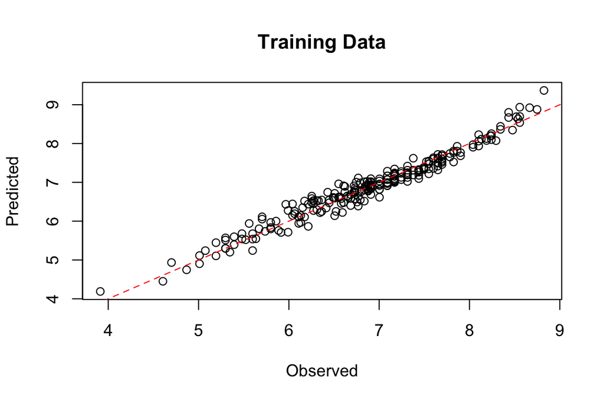

```r
plot(train_data$y, predicted_train, xlab = 'Observed', ylab = 'Predicted',
main = 'Training Data')
abline(0,1, col = 'red', lty = 2)
```

```r
rmse_train <- sqrt(mean((train_data$y - predicted_train)^2))
print(rmse_train)
```

```
## [1] 0.1759123
```

With an RMSE of 0.1759, the model demonstrates a good fit, indicating small average prediction errors.

## 1(b) Using cvFit() function for model evaluation based on crossvalidation (CV).

```r
set.seed(123)
cv_result <- cvFit(model, data = train_data, y = train_data$y, cost = rmspe, K = 5, R = 100)
```

[output not shown]

[output cut: 929 more lines]

[output not shown]

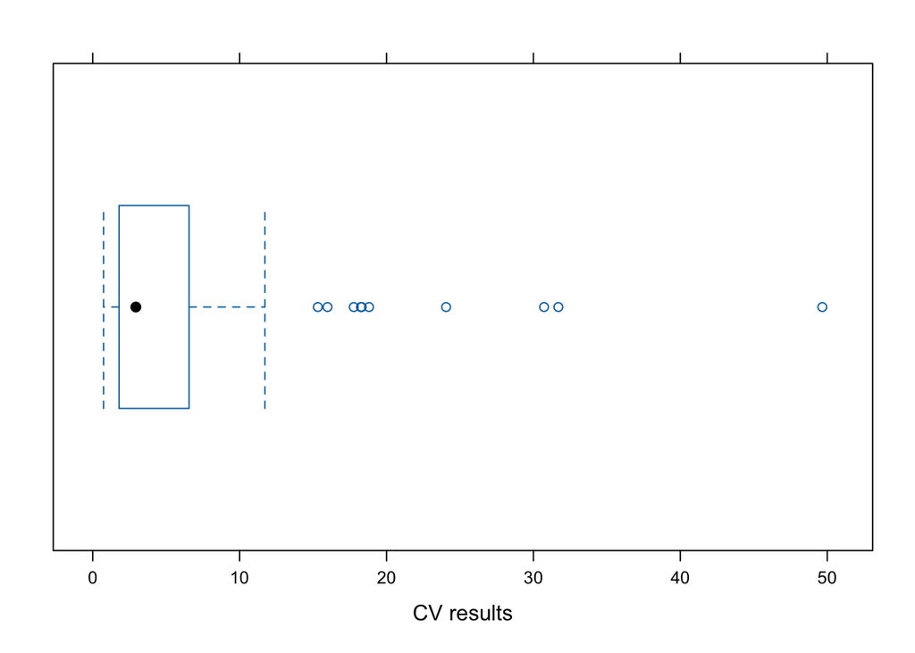

```r
plot(cv_result)
```

Most metric values fall within a narrow range (inside the box), indicating that the model shows fairly consistent results in the majority of folds. However, the presence of outliers suggests that the model performed noticeably worse in some folds.

## 1(с) Using cost=rtmspe to handle outliers.

```r
set.seed(123)
cv_result_rtmspe <- cvFit(model, data = train_data, y = train_data$y, cost = rtmspe, K = 5, R = 100)
```

[output not shown]

[output cut: 929 more lines]

[output not shown]

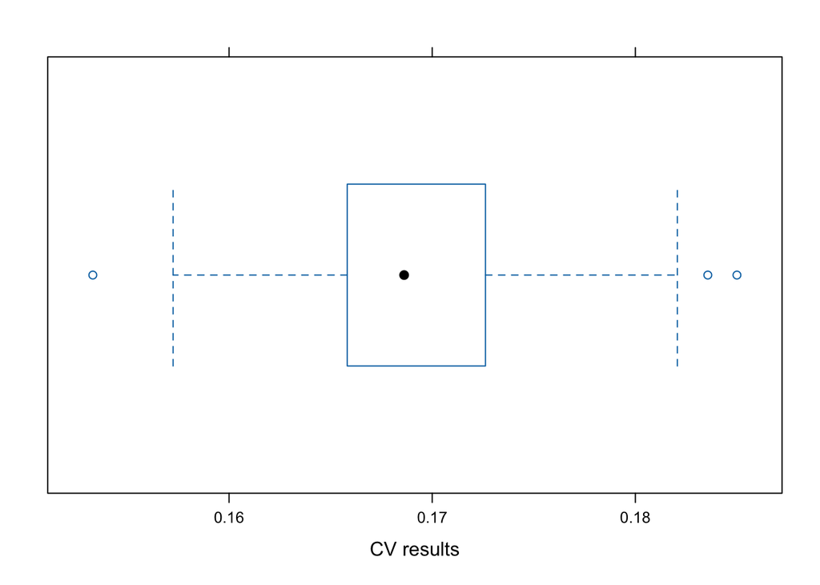

```r
plot(cv_result_rtmspe)
```

Here RTMSPE measures the percentage difference between predicted and actual values, but unlike RMSPE, it trims a certain percentage of extreme values to reduce the effect of outliers.

This trimming helps make the evaluation more representative of the model’s general performance. As we can see, the boxplot in this case shows more stable results: the median is in the center, a narrow interquartile range and fewer outliers.

## 1(d) Predicting the response for the test data and visualizing the result.

```r
predicted_test <- predict(model, test_data)
rmse_test <- sqrt(mean((test_data$y - predicted_test)^2))
print(rmse_test)
```

```
## [1] 0.4190339
```

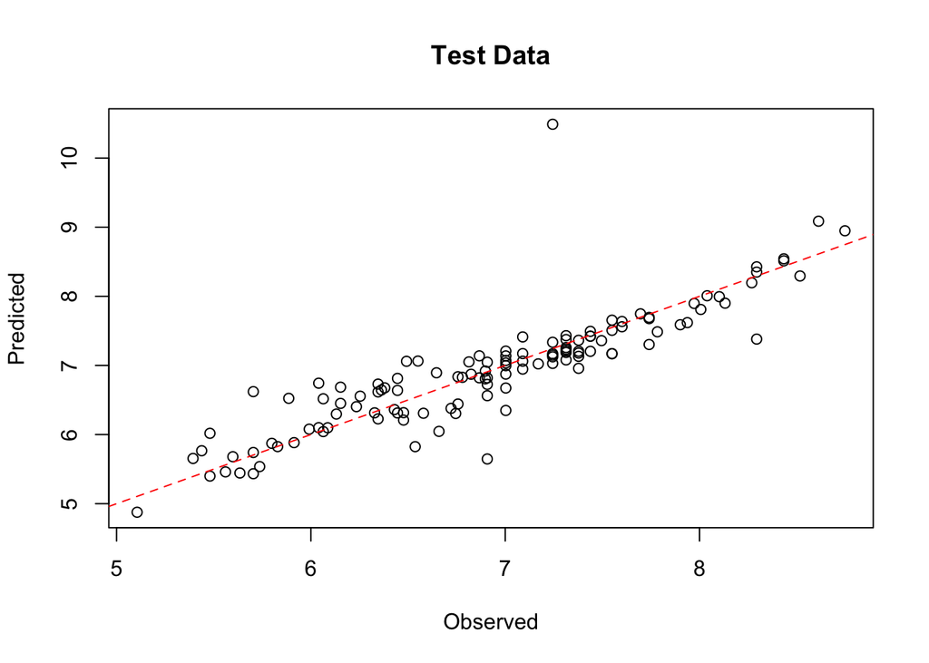

```r
plot(test_data$y, predicted_test, xlab = 'Observed', ylab = 'Predicted', main = 'Test Data')
abline(0, 1, col = 'red', lty = 2)
```

The model shows reasonable accuracy on the test data, but there is greater variance compared to the training data, which may indicate slight overfitting. The presence of outliers suggests the need for model improvement.

With an RMSE of 0.4190 on the test data, the model’s error is larger compared to the training set (vs 0.1759 on train data), indicating reduced accuracy when applied to unseen data. This suggests that the model might not generalize as well, possibly due to overfitting.

# 2. Best subset regression with the function regsubsets().

As number of predictors in the initial model is too big, in order to use regsubsets() we need first to reduce the predictors.

## 2(a) Using stepAIC to perform step-by-step elimination of insignificant predictors, and then applying the regsubsets() function to the result.

```r
reduced_model <- stepAIC(model, direction = 'backward', trace = FALSE)
summary(reduced_model)
```

```
##
## Call:
## lm(formula = y ~ START.YEAR + COMPLETION.YEAR + COMPLETION.QUARTER +
##     PhysFin1 + PhysFin2 + PhysFin3 + PhysFin5 + PhysFin6 + PhysFin8 +
##     Econ1 + Econ2 + Econ3 + Econ4 + Econ5 + Econ6 + Econ7 + Econ8 +
##     Econ9 + Econ13 + Econ16 + Econ17 + Econ18 + Econ19 + Econ1.lag1 +
##     Econ2.lag1 + Econ3.lag1 + Econ4.lag1 + Econ5.lag1 + Econ6.lag1 +
##     Econ7.lag1 + Econ9.lag1 + Econ10.lag1 + Econ11.lag1 + Econ12.lag1 +
##     Econ13.lag1 + Econ15.lag1 + Econ17.lag1 + Econ18.lag1 + Econ19.lag1 +
##     Econ1.lag2 + Econ2.lag2 + Econ3.lag2 + Econ5.lag2 + Econ6.lag2 +
##     Econ7.lag2 + Econ8.lag2 + Econ11.lag2 + Econ13.lag2 + Econ15.lag2 +
##     Econ16.lag2 + Econ18.lag2 + Econ19.lag2 + Econ1.lag3 + Econ2.lag3 +
##     Econ3.lag3 + Econ4.lag3 + Econ5.lag3, data = train_data)
##
## Residuals:
##      Min       1Q   Median       3Q      Max
## -0.55810 -0.10554  0.01286  0.12368  0.39056
##
## Coefficients:
##                      Estimate Std. Error t value Pr(>|t|)
## (Intercept)         1.018e+02  3.657e+01   2.785 0.005897 **
## START.YEAR         -1.372e+00  5.270e-01  -2.603 0.009976 **
## COMPLETION.YEAR     6.342e-02  3.144e-02   2.017 0.045105 *
## COMPLETION.QUARTER  4.664e-02  1.610e-02   2.896 0.004221 **
## PhysFin1           -3.169e-02  3.575e-03  -8.866 5.48e-16 ***
## PhysFin2            4.193e-05  3.117e-05   1.345 0.180154
## PhysFin3           -2.029e-04  1.187e-04  -1.709 0.089129 .
## PhysFin5           -3.218e-03  5.031e-04  -6.396 1.21e-09 ***
## PhysFin6            6.624e-04  9.522e-05   6.956 5.49e-11 ***
## PhysFin8            4.683e-04  2.789e-05  16.788  < 2e-16 ***
## Econ1              -2.824e-04  7.690e-05  -3.673 0.000312 ***
## Econ2               3.373e-01  9.225e-02   3.657 0.000331 ***
## Econ3               3.801e-01  6.113e-02   6.218 3.13e-09 ***
## Econ4              -1.776e-01  9.380e-02  -1.894 0.059760 .
## Econ5              -5.330e-05  9.101e-06  -5.857 2.04e-08 ***
## Econ6              -4.451e-04  1.231e-04  -3.615 0.000385 ***
## Econ7              -1.955e-01  3.155e-02  -6.196 3.51e-09 ***
## Econ8               1.135e-02  2.146e-03   5.289 3.37e-07 ***
## Econ9              -4.418e-05  1.292e-05  -3.418 0.000772 ***
## Econ13             -9.867e-05  3.683e-05  -2.679 0.008028 **
```

[output cut: 29 more lines]

```
## Econ15.lag2        -4.689e-01  1.134e-01  -4.136 5.31e-05 ***
## Econ16.lag2        -2.698e-01  6.716e-02  -4.017 8.48e-05 ***
## Econ18.lag2         9.468e-05  2.164e-05   4.375 2.00e-05 ***
## Econ19.lag2        -2.755e-06  1.185e-06  -2.325 0.021111 *
## Econ1.lag3         -2.824e-04  9.165e-05  -3.082 0.002365 **
## Econ2.lag3         -1.957e-01  5.479e-02  -3.572 0.000450 ***
## Econ3.lag3          3.788e-01  7.136e-02   5.308 3.08e-07 ***
## Econ4.lag3          1.151e-01  8.210e-02   1.402 0.162508
## Econ5.lag3         -2.753e-05  8.839e-06  -3.115 0.002122 **
## ---
## Signif. codes:  0 '***' 0.001 '**' 0.01 '*' 0.05 '.' 0.1 ' ' 1
##
## Residual standard error: 0.2034 on 190 degrees of freedom
## Multiple R-squared:  0.9579, Adjusted R-squared:  0.9452
## F-statistic: 75.81 on 57 and 190 DF,  p-value: < 2.2e-16
```

```r
initial_model <- lm(y ~ START.YEAR + COMPLETION.YEAR + COMPLETION.QUARTER +
    PhysFin1 + PhysFin2 + PhysFin3 + PhysFin5 + PhysFin6 + PhysFin8 +
    Econ1 + Econ2 + Econ3 + Econ4 + Econ5 + Econ6 + Econ7 + Econ8 +
    Econ9 + Econ13 + Econ16 + Econ17 + Econ18 + Econ19 + Econ1.lag1 +
    Econ2.lag1 + Econ3.lag1 + Econ4.lag1 + Econ5.lag1 + Econ6.lag1 +
    Econ7.lag1 + Econ9.lag1 + Econ10.lag1 + Econ11.lag1 + Econ12.lag1 +
    Econ13.lag1 + Econ15.lag1 + Econ17.lag1 + Econ18.lag1 + Econ19.lag1 +
    Econ1.lag2 + Econ2.lag2 + Econ3.lag2 + Econ5.lag2 + Econ6.lag2 +
    Econ7.lag2 + Econ8.lag2 + Econ11.lag2 + Econ13.lag2 + Econ15.lag2 +
    Econ16.lag2 + Econ18.lag2 + Econ19.lag2 + Econ1.lag3 + Econ2.lag3 +
    Econ3.lag3 + Econ4.lag3 + Econ5.lag3, data = train_data)


final_model <- step(initial_model, direction = "backward", steps = 7, trace = FALSE)

summary(final_model)
```

```
##
## Call:
## lm(formula = y ~ START.YEAR + COMPLETION.YEAR + COMPLETION.QUARTER +
##     PhysFin1 + PhysFin2 + PhysFin3 + PhysFin5 + PhysFin6 + PhysFin8 +
##     Econ1 + Econ2 + Econ3 + Econ4 + Econ5 + Econ6 + Econ7 + Econ8 +
##     Econ9 + Econ13 + Econ16 + Econ17 + Econ18 + Econ19 + Econ1.lag1 +
##     Econ2.lag1 + Econ3.lag1 + Econ4.lag1 + Econ5.lag1 + Econ6.lag1 +
##     Econ7.lag1 + Econ9.lag1 + Econ10.lag1 + Econ11.lag1 + Econ12.lag1 +
##     Econ13.lag1 + Econ15.lag1 + Econ17.lag1 + Econ18.lag1 + Econ19.lag1 +
##     Econ1.lag2 + Econ2.lag2 + Econ3.lag2 + Econ5.lag2 + Econ6.lag2 +
##     Econ7.lag2 + Econ8.lag2 + Econ11.lag2 + Econ13.lag2 + Econ15.lag2 +
##     Econ16.lag2 + Econ18.lag2 + Econ19.lag2 + Econ1.lag3 + Econ2.lag3 +
##     Econ3.lag3 + Econ4.lag3 + Econ5.lag3, data = train_data)
##
## Residuals:
##      Min       1Q   Median       3Q      Max
## -0.55810 -0.10554  0.01286  0.12368  0.39056
##
## Coefficients:
##                      Estimate Std. Error t value Pr(>|t|)
## (Intercept)         1.018e+02  3.657e+01   2.785 0.005897 **
## START.YEAR         -1.372e+00  5.270e-01  -2.603 0.009976 **
## COMPLETION.YEAR     6.342e-02  3.144e-02   2.017 0.045105 *
## COMPLETION.QUARTER  4.664e-02  1.610e-02   2.896 0.004221 **
## PhysFin1           -3.169e-02  3.575e-03  -8.866 5.48e-16 ***
## PhysFin2            4.193e-05  3.117e-05   1.345 0.180154
## PhysFin3           -2.029e-04  1.187e-04  -1.709 0.089129 .
## PhysFin5           -3.218e-03  5.031e-04  -6.396 1.21e-09 ***
## PhysFin6            6.624e-04  9.522e-05   6.956 5.49e-11 ***
## PhysFin8            4.683e-04  2.789e-05  16.788  < 2e-16 ***
## Econ1              -2.824e-04  7.690e-05  -3.673 0.000312 ***
## Econ2               3.373e-01  9.225e-02   3.657 0.000331 ***
## Econ3               3.801e-01  6.113e-02   6.218 3.13e-09 ***
## Econ4              -1.776e-01  9.380e-02  -1.894 0.059760 .
## Econ5              -5.330e-05  9.101e-06  -5.857 2.04e-08 ***
## Econ6              -4.451e-04  1.231e-04  -3.615 0.000385 ***
## Econ7              -1.955e-01  3.155e-02  -6.196 3.51e-09 ***
## Econ8               1.135e-02  2.146e-03   5.289 3.37e-07 ***
## Econ9              -4.418e-05  1.292e-05  -3.418 0.000772 ***
## Econ13             -9.867e-05  3.683e-05  -2.679 0.008028 **
```

[output cut: 29 more lines]

```
## Econ15.lag2        -4.689e-01  1.134e-01  -4.136 5.31e-05 ***
## Econ16.lag2        -2.698e-01  6.716e-02  -4.017 8.48e-05 ***
## Econ18.lag2         9.468e-05  2.164e-05   4.375 2.00e-05 ***
## Econ19.lag2        -2.755e-06  1.185e-06  -2.325 0.021111 *
## Econ1.lag3         -2.824e-04  9.165e-05  -3.082 0.002365 **
## Econ2.lag3         -1.957e-01  5.479e-02  -3.572 0.000450 ***
## Econ3.lag3          3.788e-01  7.136e-02   5.308 3.08e-07 ***
## Econ4.lag3          1.151e-01  8.210e-02   1.402 0.162508
## Econ5.lag3         -2.753e-05  8.839e-06  -3.115 0.002122 **
## ---
## Signif. codes:  0 '***' 0.001 '**' 0.01 '*' 0.05 '.' 0.1 ' ' 1
##
## Residual standard error: 0.2034 on 190 degrees of freedom
## Multiple R-squared:  0.9579, Adjusted R-squared:  0.9452
## F-statistic: 75.81 on 57 and 190 DF,  p-value: < 2.2e-16
```

As we see, the number of predictors has’t decreased after executing the step(), this may mean that according to the AIC criterion, none of the predictors turned out to be insignificant enough to be excluded from the model.

Let’s try using the regsubsets() function with the 57 predictors, that were defined in the previous steps, and with a maximum model size of 10 regressors.

```r
best_subset <- regsubsets(y ~ START.YEAR + COMPLETION.YEAR + COMPLETION.QUARTER +
    PhysFin1 + PhysFin2 + PhysFin3 + PhysFin5 + PhysFin6 + PhysFin8 +
    Econ1 + Econ2 + Econ3 + Econ4 + Econ5 + Econ6 + Econ7 + Econ8 +
    Econ9 + Econ13 + Econ16 + Econ17 + Econ18 + Econ19 + Econ1.lag1 +
    Econ2.lag1 + Econ3.lag1 + Econ4.lag1 + Econ5.lag1 + Econ6.lag1 +
    Econ7.lag1 + Econ9.lag1 + Econ10.lag1 + Econ11.lag1 + Econ12.lag1 +
    Econ13.lag1 + Econ15.lag1 + Econ17.lag1 + Econ18.lag1 + Econ19.lag1 +
    Econ1.lag2 + Econ2.lag2 + Econ3.lag2 + Econ5.lag2 + Econ6.lag2 +
    Econ7.lag2 + Econ8.lag2 + Econ11.lag2 + Econ13.lag2 + Econ15.lag2 +
    Econ16.lag2 + Econ18.lag2 + Econ19.lag2 + Econ1.lag3 + Econ2.lag3 +
    Econ3.lag3 + Econ4.lag3 + Econ5.lag3, data = train_data, nvmax = 10, really.big = TRUE)
summary(best_subset)
```

```
## Subset selection object
## Call: regsubsets.formula(y ~ START.YEAR + COMPLETION.YEAR + COMPLETION.QUARTER +
##     PhysFin1 + PhysFin2 + PhysFin3 + PhysFin5 + PhysFin6 + PhysFin8 +
##     Econ1 + Econ2 + Econ3 + Econ4 + Econ5 + Econ6 + Econ7 + Econ8 +
##     Econ9 + Econ13 + Econ16 + Econ17 + Econ18 + Econ19 + Econ1.lag1 +
##     Econ2.lag1 + Econ3.lag1 + Econ4.lag1 + Econ5.lag1 + Econ6.lag1 +
##     Econ7.lag1 + Econ9.lag1 + Econ10.lag1 + Econ11.lag1 + Econ12.lag1 +
##     Econ13.lag1 + Econ15.lag1 + Econ17.lag1 + Econ18.lag1 + Econ19.lag1 +
##     Econ1.lag2 + Econ2.lag2 + Econ3.lag2 + Econ5.lag2 + Econ6.lag2 +
##     Econ7.lag2 + Econ8.lag2 + Econ11.lag2 + Econ13.lag2 + Econ15.lag2 +
##     Econ16.lag2 + Econ18.lag2 + Econ19.lag2 + Econ1.lag3 + Econ2.lag3 +
##     Econ3.lag3 + Econ4.lag3 + Econ5.lag3, data = train_data,
##     nvmax = 10, really.big = TRUE)
## 57 Variables  (and intercept)
##                    Forced in Forced out
## START.YEAR             FALSE      FALSE
## COMPLETION.YEAR        FALSE      FALSE
## COMPLETION.QUARTER     FALSE      FALSE
## PhysFin1               FALSE      FALSE
## PhysFin2               FALSE      FALSE
## PhysFin3               FALSE      FALSE
## PhysFin5               FALSE      FALSE
## PhysFin6               FALSE      FALSE
## PhysFin8               FALSE      FALSE
## Econ1                  FALSE      FALSE
## Econ2                  FALSE      FALSE
## Econ3                  FALSE      FALSE
## Econ4                  FALSE      FALSE
## Econ5                  FALSE      FALSE
## Econ6                  FALSE      FALSE
## Econ7                  FALSE      FALSE
## Econ8                  FALSE      FALSE
## Econ9                  FALSE      FALSE
## Econ13                 FALSE      FALSE
## Econ16                 FALSE      FALSE
## Econ17                 FALSE      FALSE
## Econ18                 FALSE      FALSE
## Econ19                 FALSE      FALSE
## Econ1.lag1             FALSE      FALSE
## Econ2.lag1             FALSE      FALSE
```

[output cut: 118 more lines]

```
## 7  ( 1 )  "*"         " "         " "         " "         " "
## 8  ( 1 )  "*"         " "         " "         " "         " "
## 9  ( 1 )  "*"         " "         " "         " "         " "
## 10  ( 1 ) "*"         " "         " "         " "         " "
##           Econ1.lag3 Econ2.lag3 Econ3.lag3 Econ4.lag3 Econ5.lag3
## 1  ( 1 )  " "        " "        " "        " "        " "
## 2  ( 1 )  " "        " "        " "        " "        " "
## 3  ( 1 )  " "        " "        " "        " "        " "
## 4  ( 1 )  " "        " "        " "        " "        " "
## 5  ( 1 )  " "        " "        " "        " "        " "
## 6  ( 1 )  " "        " "        " "        " "        " "
## 7  ( 1 )  " "        " "        " "        " "        " "
## 8  ( 1 )  " "        " "        " "        " "        " "
## 9  ( 1 )  " "        " "        " "        " "        " "
## 10  ( 1 ) " "        " "        " "        " "        " "
```

We see that the function searched for the best subset for each size, starting from one predictor and up to 10 predictors. This means that she was looking for the best model with 1 predictor, with 2 predictors, and so on, up to 10 predictors.

## 2(b) Visualising the result of regsubsets() function

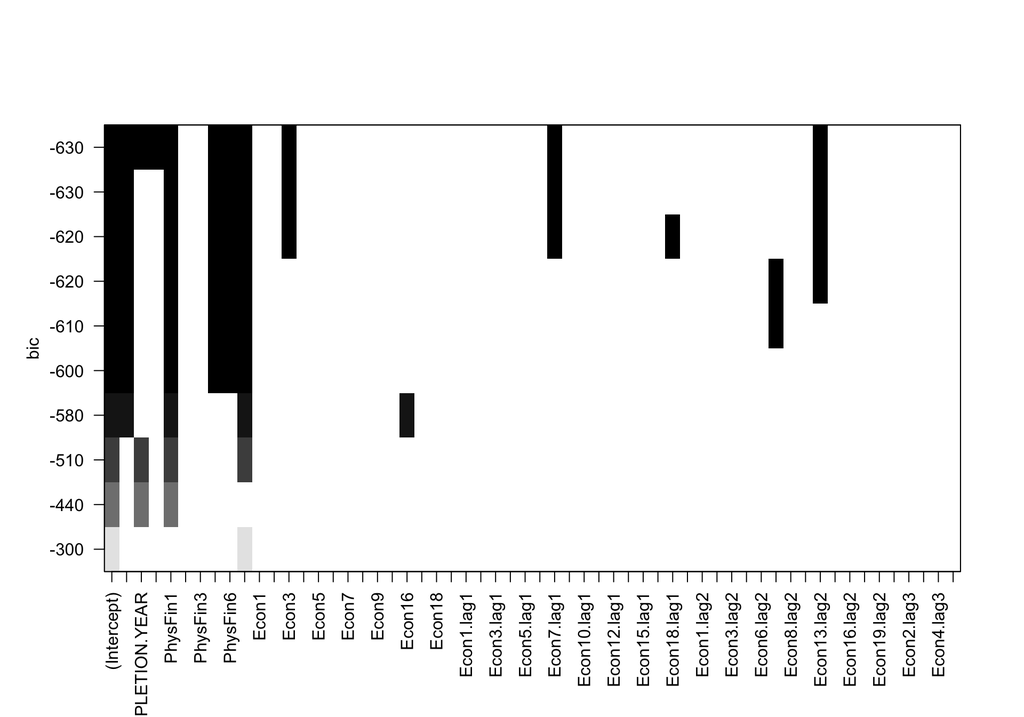

```r
plot(best_subset, scale = "bic")
```

The most significant predictors are those with the most columns going up the Y axis. The graph shows that several predictors significantly lower the BIC value. This means that they have the greatest impact on improving the model.

## 2(с) Applying lm() on the final best model and comparing the results with the previous ones(from (1b) and (1c)).

```r
final_model <- lm(y ~ START.YEAR + COMPLETION.YEAR + COMPLETION.QUARTER +
                  PhysFin1 + PhysFin5 + PhysFin6 + PhysFin8 +
                  Econ3 + Econ7.lag2 + Econ13.lag2, data = train_data)

summary(final_model)
```

```
##
## Call:
## lm(formula = y ~ START.YEAR + COMPLETION.YEAR + COMPLETION.QUARTER +
##     PhysFin1 + PhysFin5 + PhysFin6 + PhysFin8 + Econ3 + Econ7.lag2 +
##     Econ13.lag2, data = train_data)
##
## Residuals:
##     Min      1Q  Median      3Q     Max
## -0.6727 -0.1187  0.0031  0.1330  0.6804
##
## Coefficients:
##                      Estimate Std. Error t value Pr(>|t|)
## (Intercept)        -9.357e+00  8.279e-01 -11.301  < 2e-16 ***
## START.YEAR          1.015e-01  2.898e-02   3.503 0.000550 ***
## COMPLETION.YEAR     9.731e-02  2.756e-02   3.530 0.000499 ***
## COMPLETION.QUARTER  4.165e-02  1.537e-02   2.709 0.007242 **
## PhysFin1           -3.331e-02  3.464e-03  -9.618  < 2e-16 ***
## PhysFin5           -2.619e-03  4.331e-04  -6.047 5.71e-09 ***
## PhysFin6            5.049e-04  8.543e-05   5.910 1.18e-08 ***
## PhysFin8            4.470e-04  2.858e-05  15.641  < 2e-16 ***
## Econ3               4.393e-03  1.728e-03   2.541 0.011682 *
## Econ7.lag2         -4.749e-03  9.715e-04  -4.888 1.88e-06 ***
## Econ13.lag2        -3.505e-05  8.560e-06  -4.094 5.81e-05 ***
## ---
## Signif. codes:  0 '***' 0.001 '**' 0.01 '*' 0.05 '.' 0.1 ' ' 1
##
## Residual standard error: 0.2226 on 237 degrees of freedom
## Multiple R-squared:  0.9371, Adjusted R-squared:  0.9344
## F-statistic:   353 on 10 and 237 DF,  p-value: < 2.2e-16
```

The full model(from 1(a)) has a slightly better fit, as indicated by the smaller RSE and higher R² values. However, the difference with the reduced model is relatively small. Therefore, the reduced model is a good compromise between model fit quality and complexity, as reducing the number of predictors(from 73 to 10) didn’t significantly affect the model’s ability to explain the data.

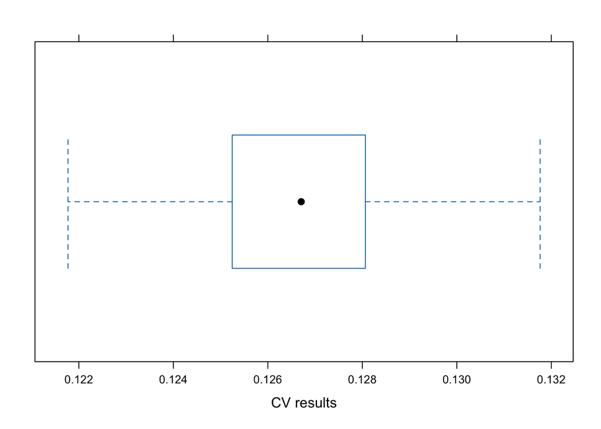

```r
set.seed(123)
cv_result_final <- cvFit(final_model, data = train_data, y = train_data$y, cost = rtmspe, K = 5, R = 100)
plot(cv_result_final)
```

Removing redundant features reduced variability and improved stability, resulting in more consistent cross-validation performance. The model now generalizes better.

Notably, the median is centered within the box, indicating a symmetric distribution, and the narrow IQR suggests low variability. The whiskers show no significant outliers, and the absence of outliers points to more stable results compared to previous models (1(b),1(c)).

## 2(d) Predicting the response for the test data and visualising the result.

```r
predicted_final_test <- predict(final_model, test_data)

rmse_final_test <- sqrt(mean((test_data$y - predicted_final_test)^2))
print(rmse_final_test)
```

```
## [1] 0.2520095
```

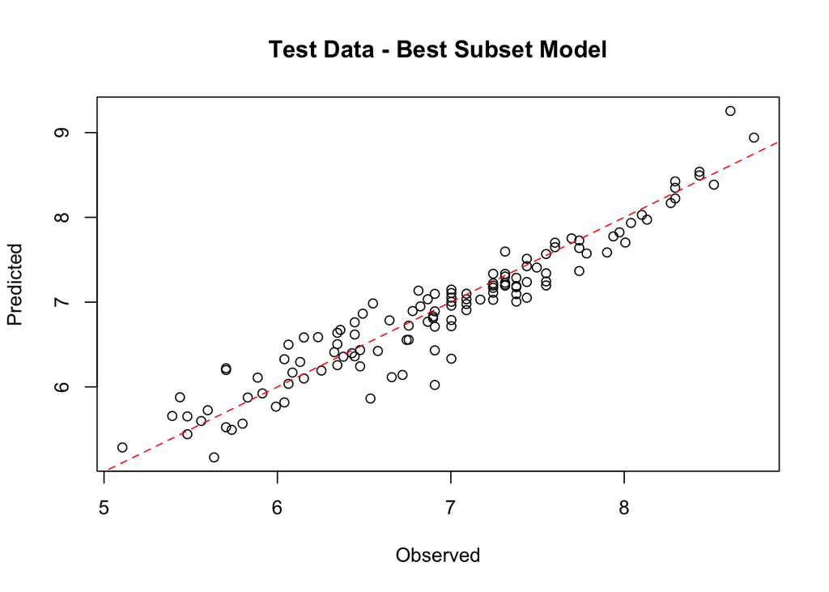

```r
plot(test_data$y, predicted_final_test, xlab = 'Observed', ylab = 'Predicted', main = 'Test Data - Best Subset Model')
abline(0, 1, col = 'red', lty = 2)
```

The RMSE on the test data decreased significantly from 0.4190 for the full model to 0.2520 for the final model. This indicates that the final model, after feature selection, has a much lower prediction error on unseen data, suggesting better generalization and improved performance.

Some points on the plot deviate noticeably from the line, which indicates the presence of prediction errors. However, their number is less than in the case of the full model(1(d)), which is an improvement.